# Module 1 - Workshop 2

## position function

Position functoin controls how the bars are displayed when there are multiple bars at the same x position. The default position is “stack”, which stacks the bars on top of each other. You can change this to “dodge” to place the bars next to each other, or “fill” to stack the bars and make them fill the same height.

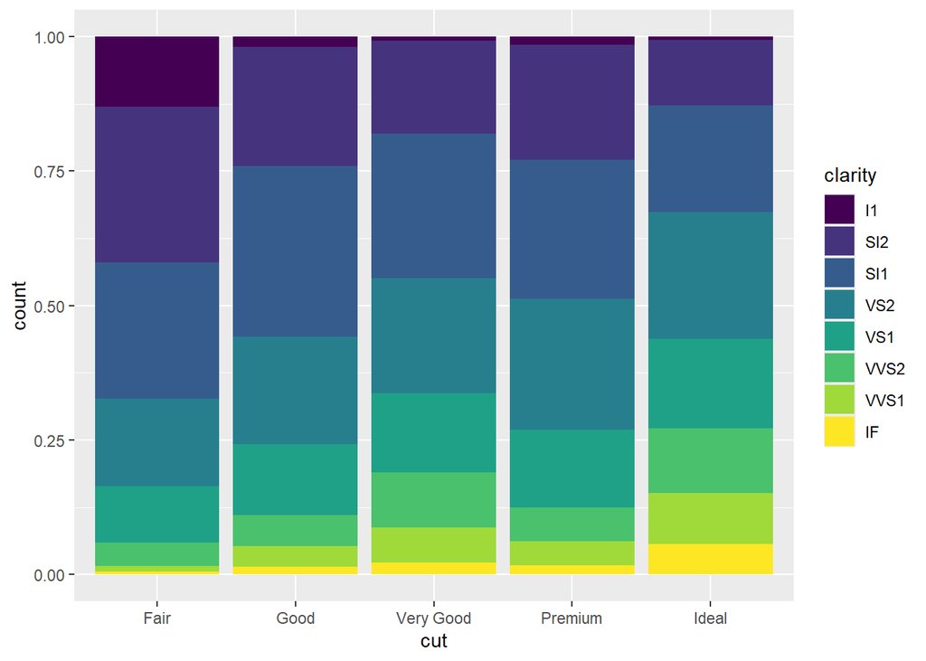

```r
ggplot(data = diamonds) +
  geom_bar(mapping = aes(x = cut, fill = clarity), position = "fill") # To create a bar chart that shows the proportion of observations in each category of cut filled by the clarity variable, you would use geom_bar() with the position = "fill" argument. This stacks the bars on top of each other and scales them to have the same height, which allows you to see the distribution of clarity within each category of cut as proportions.
```

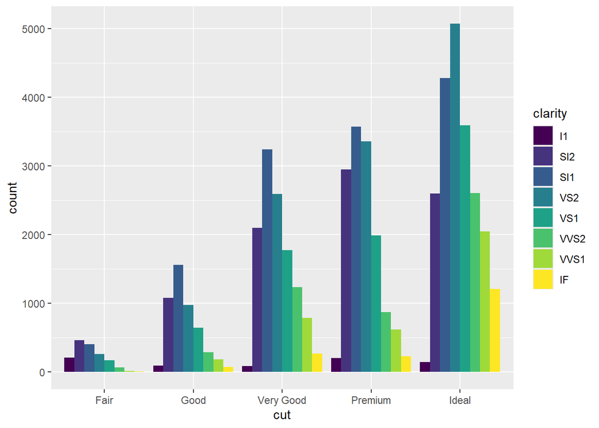

```r
ggplot(data = diamonds) +
  geom_bar(mapping = aes(x = cut, fill = clarity), position = "dodge") # To create a bar chart that places the bars next to each other for each category of cut and clarity, you would use geom_bar() with the position = "dodge" argument. This separates the bars for each category of cut and clarity, allowing you to compare the counts of observations in each category more easily.
```

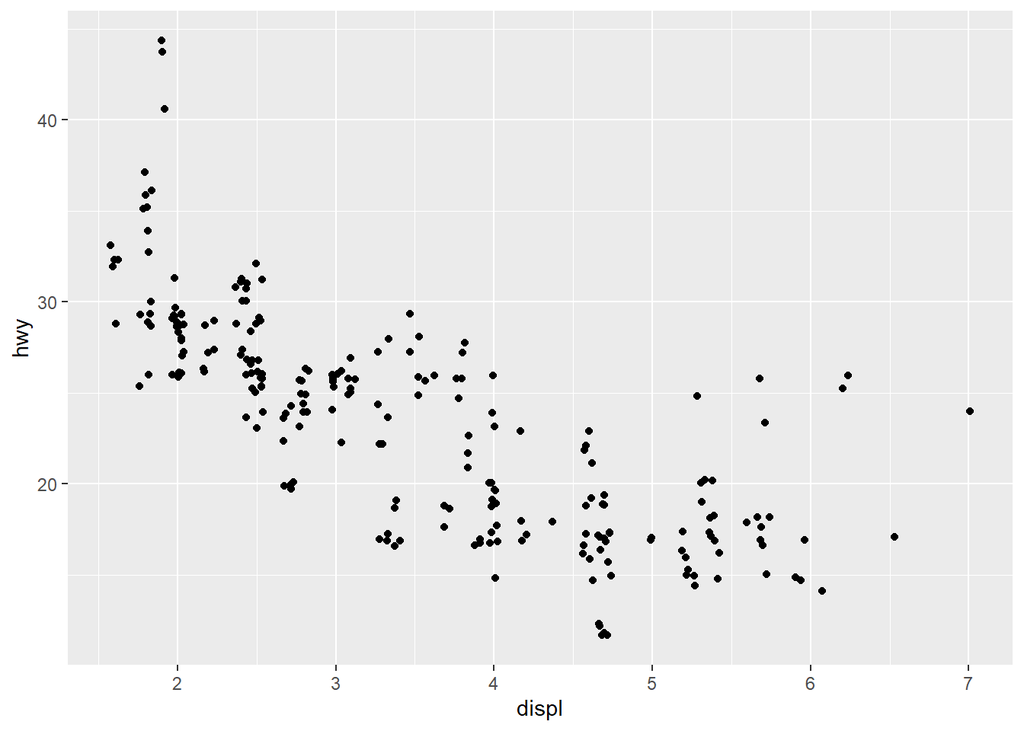

```r
ggplot(data = mpg) +
  geom_point(mapping = aes(x = displ, y = hwy), position = "jitter") # To create a scatter plot of the displ and hwy variables from the mpg dataset with points that are jittered to reduce overplotting, you would use geom_point() with the position = "jitter" argument. This adds a small amount of random noise to the position of each point, which can help to reveal patterns in the data when there are many points that overlap each other.
```

# Workshop Reflection

This workshop helped me improve my ggplot2 skills and better understand how aesthetics, geoms, facets and fitted lines can be combined to display patterns in data. It also showed me how different visual choices can affect how results are interpreted. These skills will be useful when presenting marine science data clearly.